# Poker

Bas Groeneveld

October 9, 2016

Our data set contains information about Texas Holdem poker, from a Pokerstars account (self). With 884 games, there is plenty of data to analyze. There are a few things we’d like to know up front:

- How much Net Profit we’re making (on average), per game type / speed / poker tag, and what’s our return on investment **[Chunk 4: Plot 1]**
- Whether date / time has a significant influence on our results **[Chunk 4: Plot 2,3]**
- How closely related the net winnings and the expected value are (this is basically our ‘luck factor’) **[Chunk 4: Plot 4]**
- At what spots we usually finish - this can be a good indication to determine whether we ‘bubble’ too often, or not often enough **[Chunk 4: Plot 5]**
- How much rake we pay on average, and if rake is consistant with total buyins **[Chunk 4: Plot 6]**
- How much hourly profit we make per hand, and if there are serious problem hands we need to improve on. **[Chunk 4: Plot 7]**
- Dig deeper into correlation between variables **[Chunk 5: Corrplot 1]**
- Lastly, we look at some more complicated in-game stats **[Chunk 6]**

# Let’s start by making our data suitable for analysis.

```r
#Numerics & integers
poker$Total.Buy.In <- as.numeric(sub("\\$","", poker$Total.Buy.In))
poker$Rake <- as.numeric(sub("\\$","", poker$Rake))
poker$Rebuy <- as.numeric(sub("\\$","", poker$Rebuy))
poker$Winnings <- as.numeric(sub("\\$","", poker$Winnings))
poker$Net.Winnings...USD <- as.numeric(sub("\\$","", poker$Net.Winnings...USD))
poker$X.EV <- as.numeric(sub("\\$","", poker$X.EV))

#We'd like to convert tourney time played to minutes. Since the 'm' doesn't do much in R, and limits our analysis capabilities, we subset the value to have tourney time played only represent a number.
poker$Tourney.Time.Played <- as.numeric(sub('m$',"", poker$Tourney.Time.Played))

#Factors
poker$Speed <- as.factor(poker$Speed)
poker$Table.size <- as.factor(poker$Table.size)
poker$Tag <- as.factor(poker$Tag)

#Date & time
glct <- Sys.getlocale("LC_TIME")
poker$Start.Time <- as.Date(poker$Start.Time, "%m/%d")

#Data frame
poker <- as.data.frame(poker)

#Targeted subsetting & filtering: we don't want Spin and Go and the 18-person format to appear in our further analysis, because they aren't representative for the entire table. We could have done this, but with an n lower than 10 this wouldn't provide very informative results. Same goes for the 'Rebuy' column.
poker <- subset.data.frame(poker, poker$Tag !="Spin and Go")
poker <- subset.data.frame(poker, poker$Tag != "18-Person")
poker <- poker[-5]
poker <- na.omit(poker)
```

# There is a lot to analyze in the world of poker. Let’s take a look at both hands and additional computed values.

```r
#Adding columns
poker$ProfitPerHour <- poker$Net.Winnings...USD / (poker$Tourney.Time.Played / 60)
poker$EquityDiff <- poker$Net.Winnings...USD - poker$X.EV

#Hands: we first create two lists for both the suit and the rank of a card. Afterwards, we make sure every row has a hand, by sampling the amount of rows that are present in the poker table. We use hands in a way that they are 1:1 with games (which is obviously unrealistic) so there's quite some improvement here, but for now 'it does the job' and we're not data scientists just yet. Thirdly, we paste the "of" string so the output is something like 'Ace of Spades'. Finally, we make an additional subset for each suit and output that as a (cleaned) data frame. This is for future use.

Suits <- as.list(c("Clubs", "Diamonds", "Hearts", "Spades"))
Ranks <- as.list(c(2:10,"Jack","King","Queen","Ace"))

poker$Suits <- sample(Suits, 872, replace=TRUE)
poker$Ranks <- sample(Ranks, 872, replace=TRUE)
poker$Merged <- paste(poker$Ranks, "of", poker$Suits)
poker$Merged <- as.factor(poker$Merged)

#We could have also used [ or dplyr's filter instead of grepl, but grepl seems to be more readable syntax. We're not too concerend with performance here.

pokerClubs <- subset(poker, grepl("Clubs", poker$Merged))
pokerClubs <- as.data.frame(pokerClubs)

pokerDiamonds <- subset(poker, grepl("Diamonds", poker$Merged))
pokerDiamonds <- as.data.frame(pokerDiamonds)

pokerHearts <- subset(poker, grepl("Hearts", poker$Merged))
pokerHearts <- as.data.frame(pokerHearts)

pokerSpades <- subset(poker, grepl("Spades", poker$Merged))
pokerSpades <- as.data.frame(pokerSpades)
```

Now, we’re ready to start plotting - both qplots and basic R plots

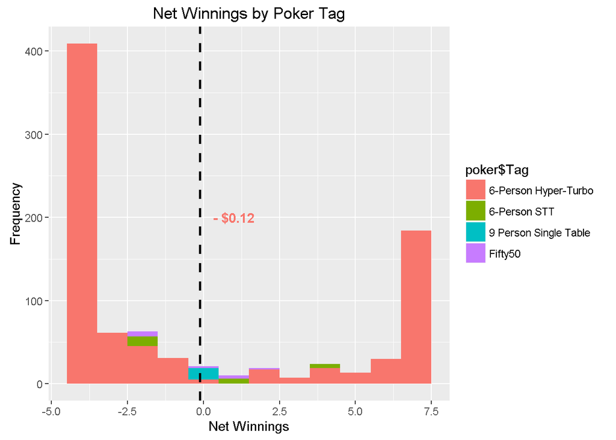

```r
#Plot1: We'd like to see what Net Winnings we're getting for each Poker Tag. We also put a vertical dashed line in there that represents the mean value, so we can better interpret the histogram.

plot1 <- qplot(poker$Net.Winnings...USD, data = poker, geom = "histogram", fill = poker$Tag, binwidth = 1, xlab = "Net Winnings", ylab = "Frequency") + labs(title = "Net Winnings by Poker Tag") + geom_vline(xintercept = (mean(poker$Net.Winnings...USD)), colour = "black", linetype = "dashed", size = 1) + geom_text(aes(1, 200, label = "- $0.12", fontface = "bold", colour = "red")) + guides(colour=FALSE)
plot1
```

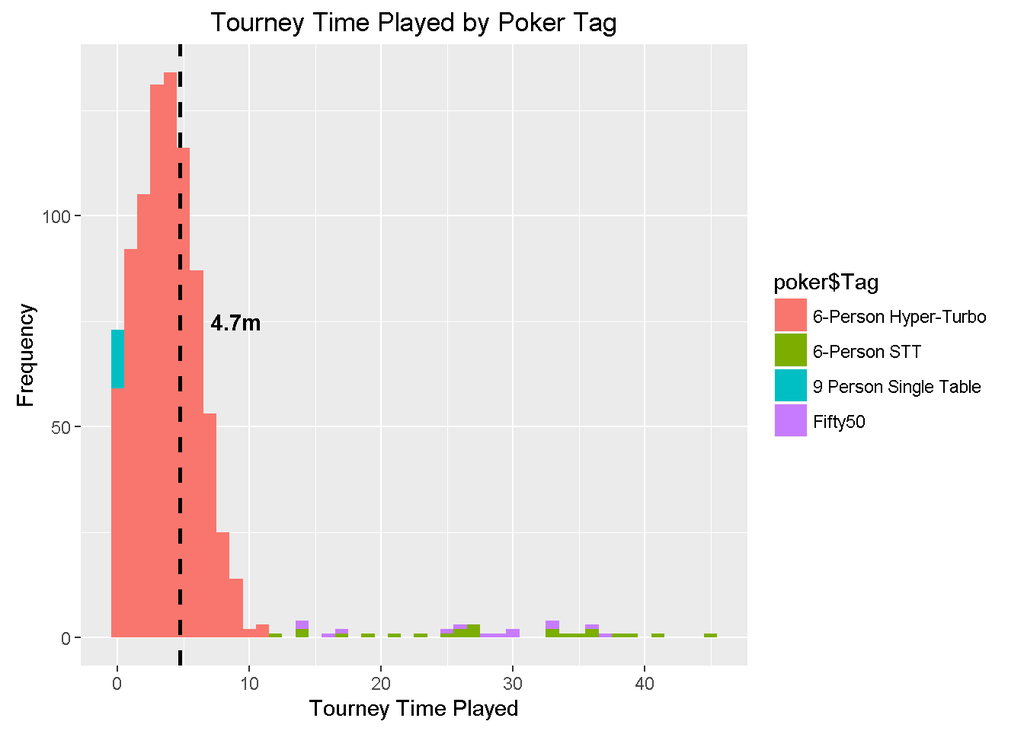

```r
#Subsequently, let's get the RoI while we're at it

PokerBuyInSum <- sum(poker$Total.Buy.In)
PokerNetSum <- sum(poker$Net.Winnings...USD)
PokerRoI <- (PokerNetSum / PokerBuyInSum) * 100

#Plot2: We'd like to see if time is a factor that influences the result of each Poker Tag. We'll further look at this with correlation, but for now, we also use a histogram with the mean value line described in plot1.

plot2 <- qplot(poker$Tourney.Time.Played, data = poker, geom = "histogram", fill = poker$Tag, binwidth = 1, xlab = "Tourney Time Played", ylab = "Frequency") + labs(title = "Tourney Time Played by Poker Tag") + geom_vline(xintercept = (mean(poker$Tourney.Time.Played)), colour = "black", linetype = "dashed", size = 1) + geom_text(aes(9, 75, label = "4.7m", fontface = "bold", colour2 = "black")) + guides(colour=FALSE)
plot2
```

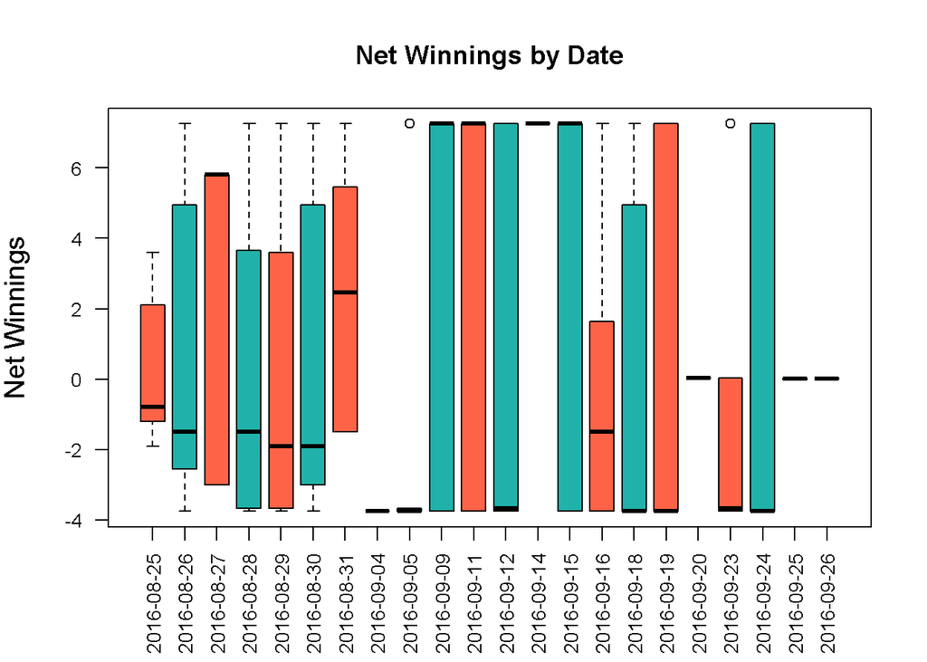

```r
#Additional calculations

PokerHours<- sum(poker$Tourney.Time.Played / 60)
PokerHourlyMeanLoss <- mean(poker$Net.Winnings...USD) * 872 / 60

#Plot3: We created a boxplot to see on what days we were more succesful and how big the differences were during the day (or 'swings' in poker). This unfortunately didn't really gave us the result to conduct further analysis on, since values are relatively close to each other and don't show a clear enough win/loss trend.

plot3 <- boxplot(poker$Net.Winnings...USD ~ poker$Start.Time, data = poker, main = "Net Winnings by Date", ylab = "Net Winnings", col=(c("tomato1","lightseagreen")), boxwex = 0.75, las = 2, cex.axis = 0.875, cex.lab = 1.25)
```

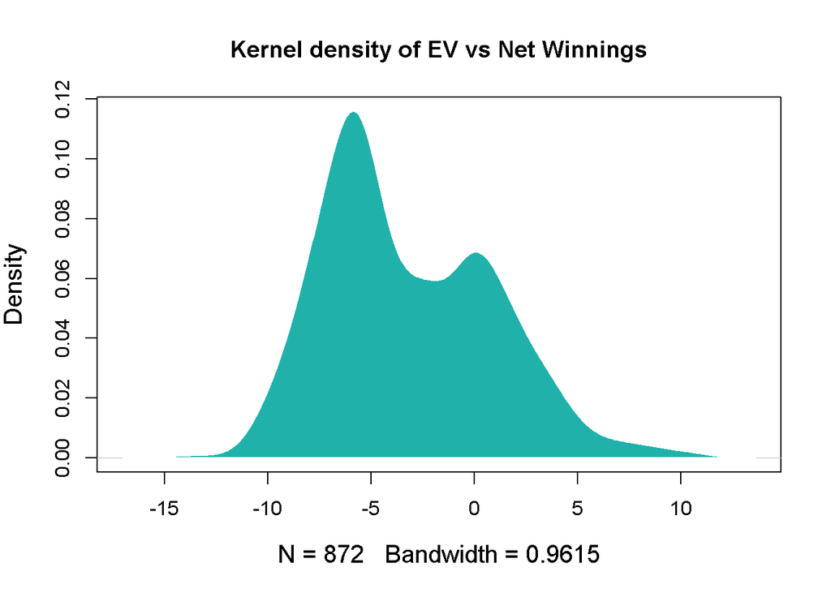

```r
#Plot4: We created a density plot in which kernel density estimates are displayed for EV vs Net Winnings.

plot4 <- density(poker$EquityDiff)
plot(plot4, main = "Kernel density of EV vs Net Winnings", ylab = "Density", cex.lab = 1.25)
polygon(plot4, col = "lightseagreen", border = "white")
```

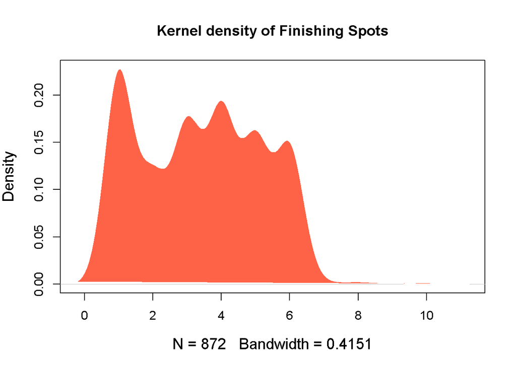

```r
#The model clearly shows that EquityDiff has a higher density for negative values, which translates into a higher expected value than our actual Net Winnings.

#Plot5: We created a density plot in which kernel density estimates are displayed for finishing spots.

plot5 <- density(poker$Finish)
plot(plot5, main = "Kernel density of Finishing Spots", ylab = "Density", cex.lab = 1.25)
polygon(plot5, col = "tomato1", border = "white")
```